# Lab-02

Caio Oliveira

28 de novembro de 2016

```r
library(readr)
library(dplyr)
graduados <- read_csv("graduados.csv", col_types = cols(matricula = col_character())) %>%
  mutate(matricula = as.factor(matricula))
head(graduados)
```

```
## # A tibble: 6 × 7
##   matricula codigo_disciplina periodo
##      <fctr>             <int>   <dbl>
## 1 183429266           1411169  2013.2
## 2 183429266           1411178  2013.2
## 3 183429266           1411178  2014.1
## 4 183429266           1411183  2014.1
## 5  46876753           1411183  2014.1
## 6 183429266           1411184  2014.2
## # ... with 4 more variables: disciplina <chr>, creditos <int>,
## #   media <dbl>, periodo_ingresso <dbl>
```

Vamos adicionar o CRA ao data frame dos alunos graduados. Mas antes, vamos dar uma olhada nos dados para ver como estão:

```r
str(graduados)
```

```
## Classes 'tbl_df', 'tbl' and 'data.frame':    16751 obs. of  7 variables:
##  $ matricula        : Factor w/ 412 levels "103343436","104343425",..: 63 63 63 63 379 63 379 63 379 63 ...
##  $ codigo_disciplina: int  1411169 1411178 1411178 1411183 1411183 1411184 1411184 1411185 1411185 1411188 ...
##  $ periodo          : num  2013 2013 2014 2014 2014 ...
##  $ disciplina       : chr  "Paradigmas de Ling. de Programação" "Sistemas de Informação I" "Sistemas de Informação I" "Laboratório de Engenharia de Software" ...
##  $ creditos         : int  4 4 4 2 2 2 2 4 4 4 ...
##  $ media            : num  8.5 4.3 7 6.3 8.3 5.4 7 7.1 6.2 5 ...
##  $ periodo_ingresso : num  2013 2013 2013 2013 2012 ...
```

```r
summary(graduados)
```

```
##       matricula     codigo_disciplina    periodo      disciplina
##  1865571312:   73   Min.   :1108089   Min.   :2002   Length:16751
##  3860036619:   68   1st Qu.:1305220   1st Qu.:2006   Class :character
##  3857036627:   67   Median :1411177   Median :2008   Mode  :character
##  1669020028:   65   Mean   :1344411   Mean   :2008
##  3858036635:   65   3rd Qu.:1411187   3rd Qu.:2010
##  106343549 :   64   Max.   :1411197   Max.   :2015
##  (Other)   :16349
##     creditos         media        periodo_ingresso
##  Min.   :2.000   Min.   : 0.000   Min.   :2002
##  1st Qu.:4.000   1st Qu.: 6.500   1st Qu.:2004
##  Median :4.000   Median : 7.500   Median :2006
##  Mean   :3.869   Mean   : 7.247   Mean   :2006
##  3rd Qu.:4.000   3rd Qu.: 8.400   3rd Qu.:2008
##  Max.   :6.000   Max.   :10.000   Max.   :2014
##                  NA's   :252
```

```r
View(graduados)
graduados <- graduados %>%
  arrange(matricula)
```

Como vemos, há diversas médias faltantes (NAs). Além disso, alguns alunos pagaram a mesma disciplina mais de uma vez (reprovações).

Como lidar com isso?

. . . . .

```r
graduados.clean <- graduados %>%
  filter(!is.na(media))

summary(graduados.clean)
```

```
##       matricula     codigo_disciplina    periodo      disciplina
##  1865571312:   72   Min.   :1108089   Min.   :2002   Length:16499
##  1669020028:   65   1st Qu.:1305220   1st Qu.:2006   Class :character
##  106343549 :   63   Median :1411177   Median :2008   Mode  :character
##  3860036619:   61   Mean   :1345254   Mean   :2008
##  398706298 :   61   3rd Qu.:1411187   3rd Qu.:2010
##  3857036627:   60   Max.   :1411197   Max.   :2015
##  (Other)   :16117
##     creditos         media        periodo_ingresso
##  Min.   :2.000   Min.   : 0.000   Min.   :2002
##  1st Qu.:4.000   1st Qu.: 6.500   1st Qu.:2004
##  Median :4.000   Median : 7.500   Median :2006
##  Mean   :3.868   Mean   : 7.247   Mean   :2006
##  3rd Qu.:4.000   3rd Qu.: 8.400   3rd Qu.:2008
##  Max.   :6.000   Max.   :10.000   Max.   :2014
##
```

```r
View(graduados.clean)
```

Agora, vamos calcular o CRA dos alunos:

```r
graduados.cra <- graduados.clean %>%
  group_by(matricula) %>%
  mutate(cra.contrib = media*creditos) %>%
  summarise(cra = sum(cra.contrib)/sum(creditos))

head(graduados.cra)
```

```
## # A tibble: 6 × 2
##   matricula      cra
##      <fctr>    <dbl>
## 1 103343436 8.357317
## 2 104343425 8.113253
## 3 104343426 7.808219
## 4 104343427 7.453226
## 5 104343429 7.722892
## 6 104343430 8.190909
```

Agora, como ajustar os dados para calcular o modelo? Qual seria o formato ideal?

. . . . .

```r
library(reshape2)

graduados.model.input <- graduados.clean %>%
  group_by(matricula,disciplina)  %>%
  filter(media == max(media)) %>%
  ungroup() %>%
  select(matricula,disciplina,media) %>%
  mutate(disciplina = as.factor(gsub(" ",".",disciplina))) %>%
  dcast(matricula ~ disciplina, mean) %>%
  merge(graduados.cra)
head(graduados.model.input)
```

```
##   matricula Álgebra.Linear.I Álgebra.Vetorial.e.Geometria.Analítica
## 1 103343436              NaN                                    9.5
## 2 104343425              7.8                                    7.8
## 3 104343426              NaN                                    NaN
## 4 104343427              NaN                                    NaN
## 5 104343429              NaN                                    7.8
## 6 104343430              NaN                                    NaN
##   Análise.e.Técnica.de.Algoritmos
## 1                             9.3
## 2                             7.0
## 3                             6.0
## 4                             7.0
## 5                             5.6
## 6                             9.2
##   Aval..de.Desempenho.de.Sistemas.Discretos Banco.de.Dados.I
```

[output cut: 132 more lines]

```r
View(graduados.model.input)
```

Pegamos os dados de cada uma das disciplinas em variáveis

```r
#primeiro periodo
CI <- graduados.model.input$Cálculo.Diferencial.e.Integral.I
AV <- graduados.model.input$Álgebra.Vetorial.e.Geometria.Analítica
IC <- graduados.model.input$Introdução.à.Computação
LPI <- graduados.model.input$Laboratório.de.Programação.I
PI <- graduados.model.input$Programação.I
LPT <- graduados.model.input$Leitura.e.Produção.de.Textos

#segundo periodo

TG <- graduados.model.input$Teoria.dos.Grafos
PII <- graduados.model.input$Programação.II
LPII <- graduados.model.input$Laboratório.de.Programação.II
CII <- graduados.model.input$Cálculo.Diferencial.e.Integral.II
FFC <- graduados.model.input$Fundamentos.de.Física.Clássica
MD <- graduados.model.input$Matemática.Discreta
```

Regressão para o primeiro período

```r
mycra1 <- lm(cra~CI + AV+ IC + PI + LPI + LPT, graduados.model.input)
summary(mycra1)
```

```
##
## Call:
## lm(formula = cra ~ CI + AV + IC + PI + LPI + LPT, data = graduados.model.input)
##
## Residuals:
##      Min       1Q   Median       3Q      Max
## -2.53290 -0.31108  0.07564  0.37949  1.31148
##
## Coefficients:
##             Estimate Std. Error t value Pr(>|t|)
## (Intercept)  0.89445    0.38666   2.313 0.021423 *
## CI           0.11604    0.02803   4.141 4.57e-05 ***
## AV           0.12305    0.03221   3.821 0.000164 ***
## IC           0.32061    0.04853   6.606 1.94e-10 ***
## PI           0.06425    0.04076   1.576 0.116054
## LPI          0.08620    0.04219   2.043 0.041974 *
## LPT          0.11915    0.03672   3.245 0.001315 **
## ---
## Signif. codes:  0 '***' 0.001 '**' 0.01 '*' 0.05 '.' 0.1 ' ' 1
##
## Residual standard error: 0.5668 on 284 degrees of freedom
##   (121 observations deleted due to missingness)
## Multiple R-squared:  0.5488, Adjusted R-squared:  0.5392
## F-statistic: 57.56 on 6 and 284 DF,  p-value: < 2.2e-16
```

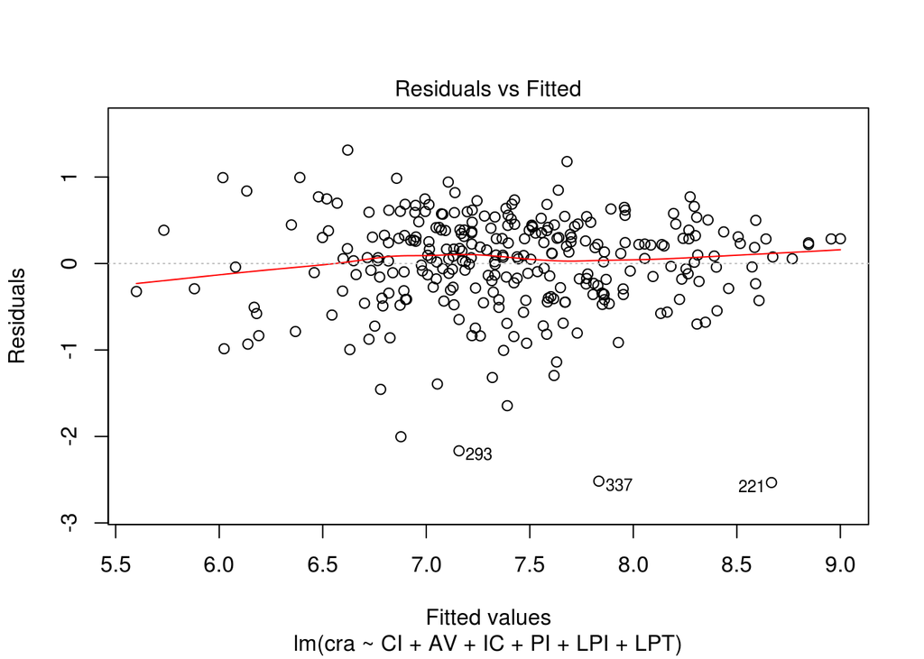

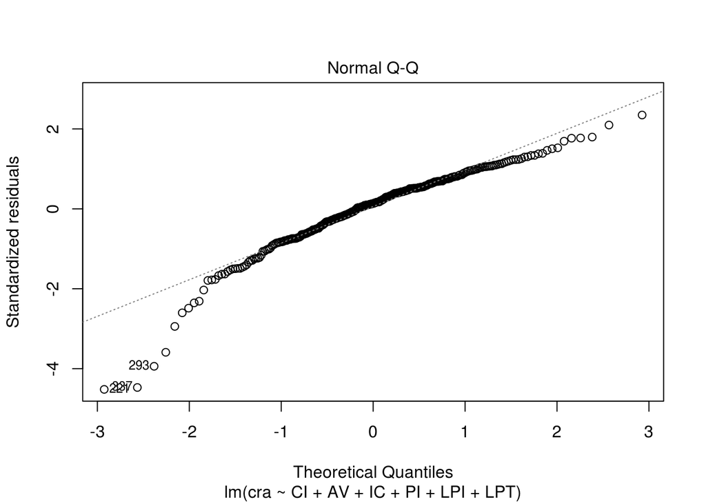

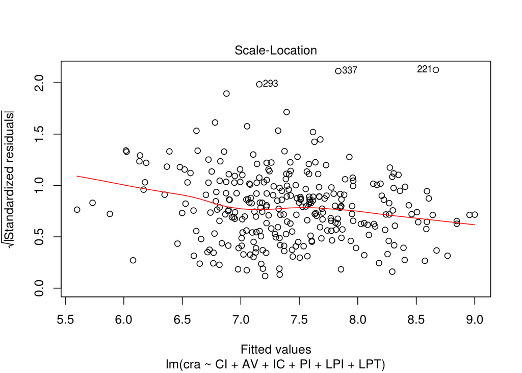

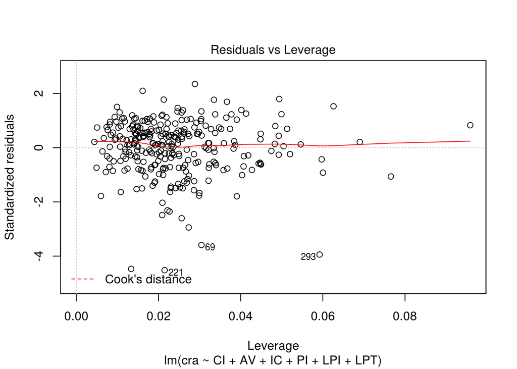

```r
plot(mycra1)
```

Regressão para o segundo periodo

```r
mycra2 <- lm(cra~CII + FFC + LPII  + PII + MD + TG, graduados.model.input)
summary(mycra2)
```

```
##
## Call:
## lm(formula = cra ~ CII + FFC + LPII + PII + MD + TG, data = graduados.model.input)
##
## Residuals:
##      Min       1Q   Median       3Q      Max
## -1.59303 -0.35328  0.08232  0.34269  1.01093
##
## Coefficients:
##             Estimate Std. Error t value Pr(>|t|)
## (Intercept) 2.101453   0.488158   4.305 3.76e-05 ***
## CII         0.018291   0.048695   0.376  0.70795
## FFC         0.039475   0.053422   0.739  0.46160
## LPII        0.004893   0.056411   0.087  0.93105
## PII         0.257116   0.086630   2.968  0.00371 **
## MD          0.266726   0.054252   4.916 3.27e-06 ***
## TG          0.129179   0.052604   2.456  0.01570 *
## ---
## Signif. codes:  0 '***' 0.001 '**' 0.01 '*' 0.05 '.' 0.1 ' ' 1
##
## Residual standard error: 0.5048 on 105 degrees of freedom
##   (300 observations deleted due to missingness)
## Multiple R-squared:  0.6628, Adjusted R-squared:  0.6435
## F-statistic:  34.4 on 6 and 105 DF,  p-value: < 2.2e-16
```

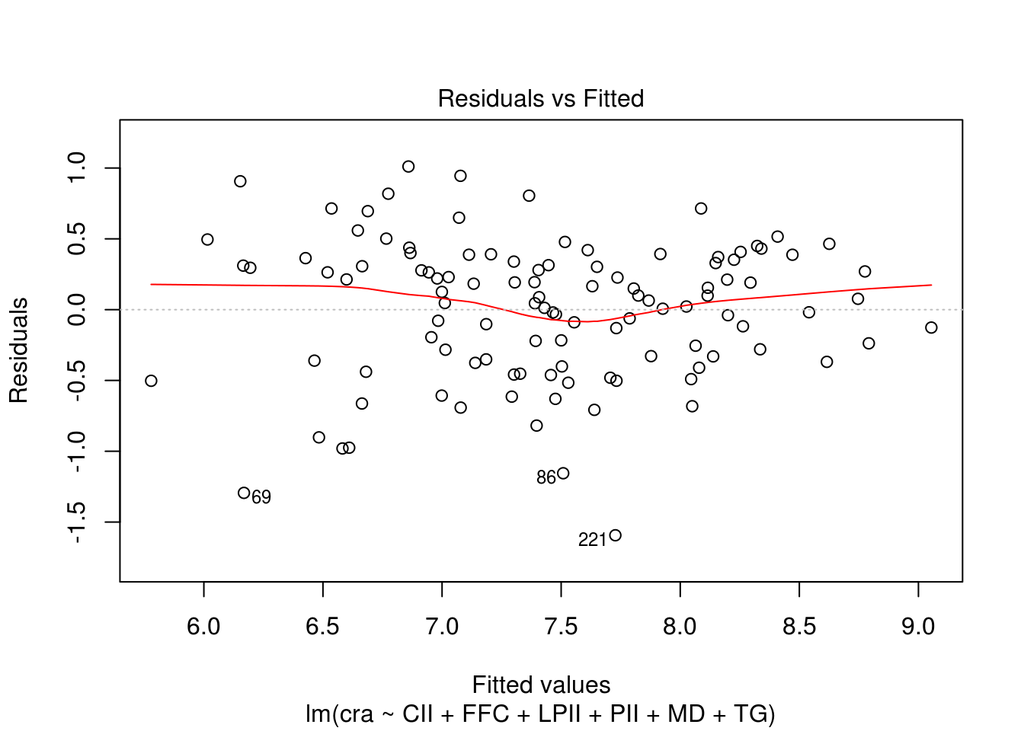

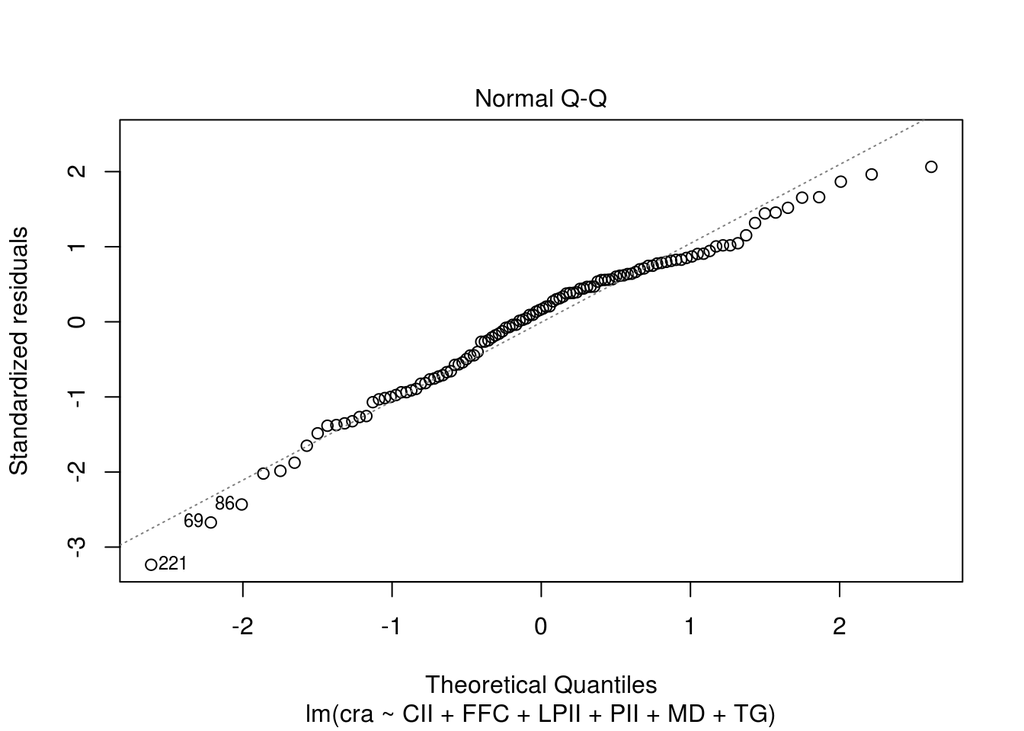

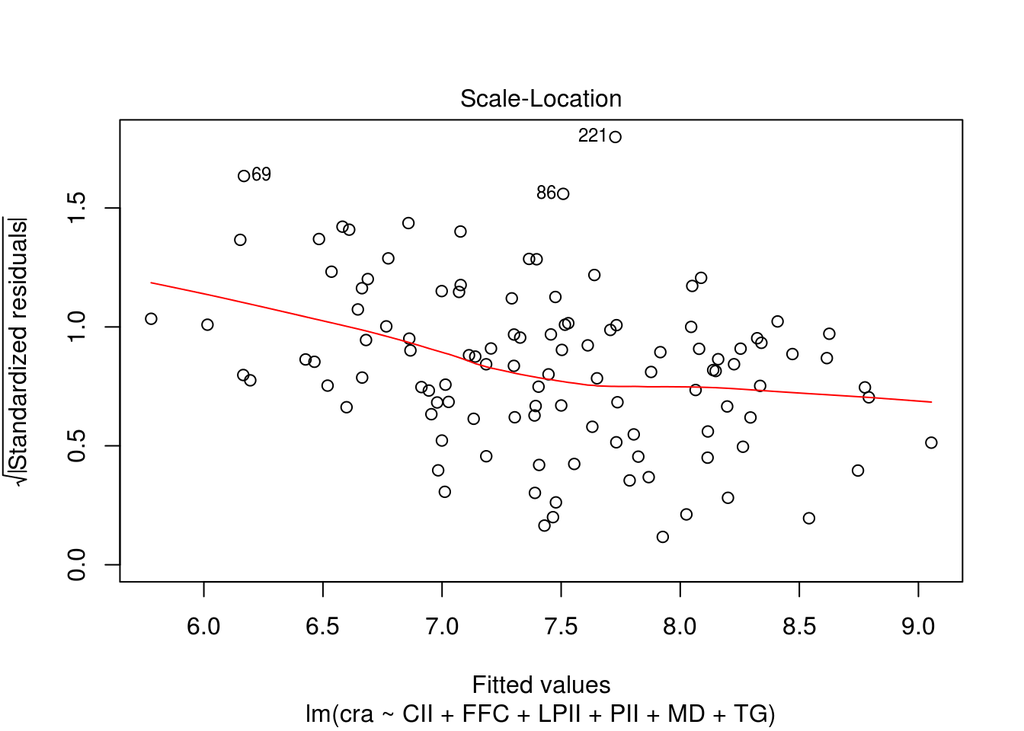

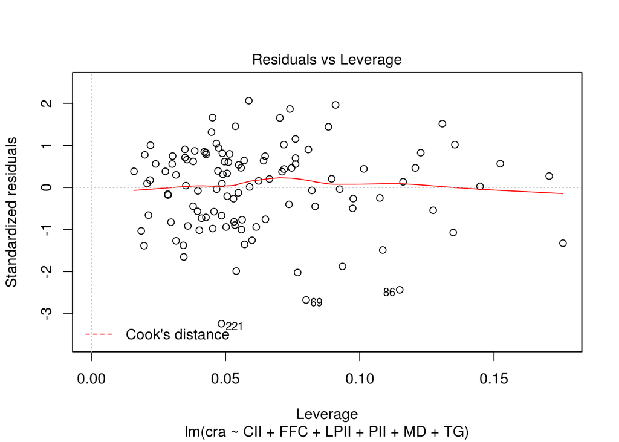

```r
plot(mycra2)
```

….

Podemos então responder as perguntas agora.

### Um modelo de regressão múltipla com todas as variáveis é plausível para explicar a variação em y? Em que grau?

A resposta é não, pois temos variáveis que são desprezíveis no modelo, que só acrescentam ruidos, como prodemos ver na sumarização dos dados tanto para o primeiro período como para o segundo. Em grau 4 se formos considerar as cadeiras relevantes dos dois períodos estudados.

….

### Todas as variáveis são úteis para o modelo de regressão?

Não, por exemplo Laboratório de Programação dois que tem um p-valor alto e contribui pouquíssimo para o resultado.

….

### Se a resposta para a pergunta anterior foi não, construa um novo modelo sem essas variáveis e o compare ao modelo com todas as variáveis (e.g. em termos de R2 e RSE).

Para somente o primeiro período temos:

```r
mycra1.best <- lm(cra~CI + AV+ IC, graduados.model.input)
summary(mycra1.best)
```

```
##
## Call:
## lm(formula = cra ~ CI + AV + IC, data = graduados.model.input)
##
## Residuals:
##      Min       1Q   Median       3Q      Max
## -2.36516 -0.34520  0.07261  0.40199  1.49808
##
## Coefficients:
##             Estimate Std. Error t value Pr(>|t|)
## (Intercept)  1.85674    0.34208   5.428 1.21e-07 ***
## CI           0.14063    0.02906   4.839 2.12e-06 ***
## AV           0.14654    0.03364   4.356 1.84e-05 ***
## IC           0.42003    0.04729   8.882  < 2e-16 ***
## ---
## Signif. codes:  0 '***' 0.001 '**' 0.01 '*' 0.05 '.' 0.1 ' ' 1
##
## Residual standard error: 0.5977 on 290 degrees of freedom
##   (118 observations deleted due to missingness)
## Multiple R-squared:  0.4988, Adjusted R-squared:  0.4936
## F-statistic: 96.21 on 3 and 290 DF,  p-value: < 2.2e-16
```

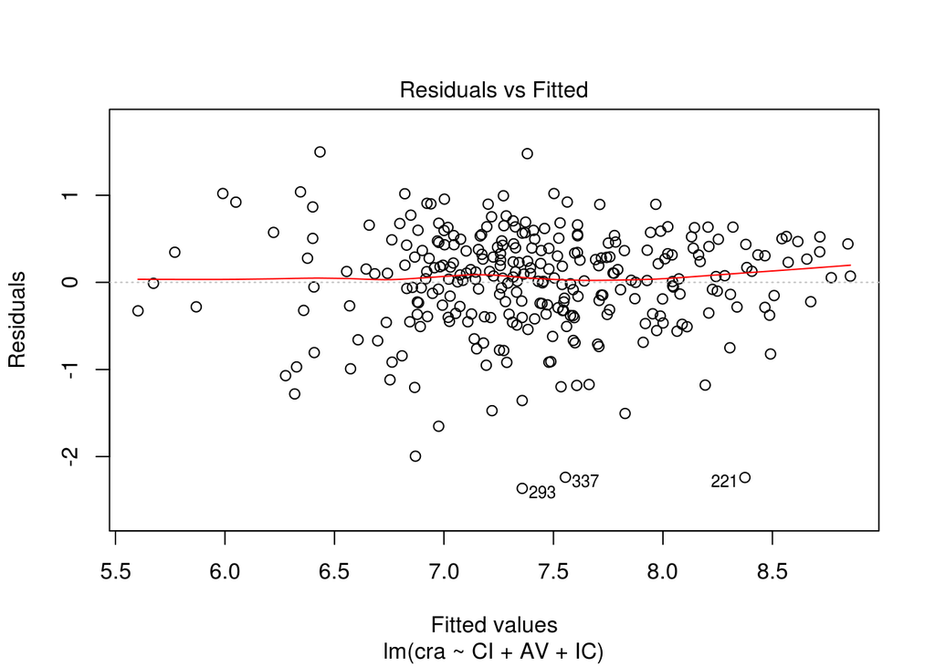

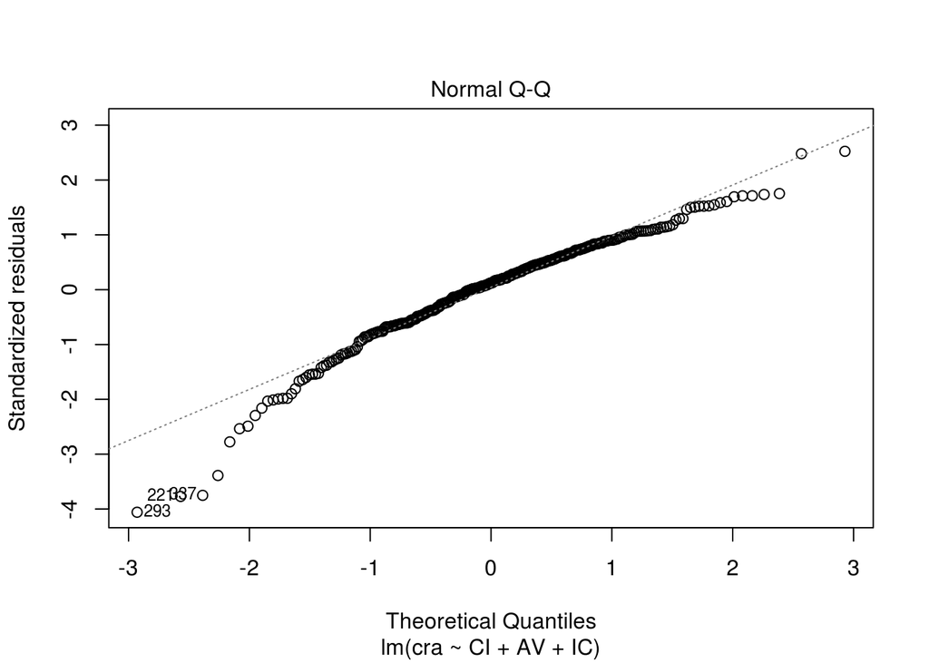

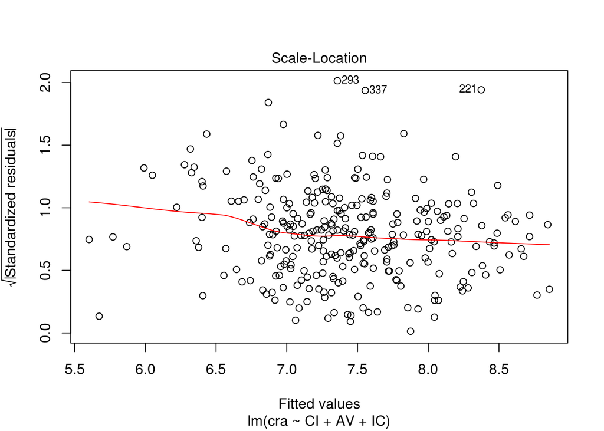

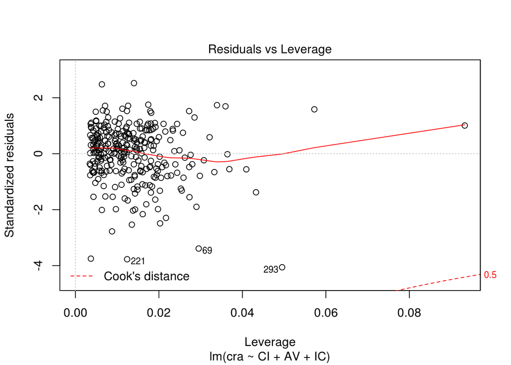

```r
plot(mycra1.best)
```

Para somente o segundo período temos:

```r
mycra2.best <- lm(cra~MD, graduados.model.input)
summary(mycra2.best)
```

```
##
## Call:
## lm(formula = cra ~ MD, data = graduados.model.input)
##
## Residuals:
##      Min       1Q   Median       3Q      Max
## -2.60260 -0.30272  0.07656  0.47007  1.41874
##
## Coefficients:
##             Estimate Std. Error t value Pr(>|t|)
## (Intercept)   4.6578     0.2230   20.89   <2e-16 ***
## MD            0.3891     0.0311   12.51   <2e-16 ***
## ---
## Signif. codes:  0 '***' 0.001 '**' 0.01 '*' 0.05 '.' 0.1 ' ' 1
##
## Residual standard error: 0.6952 on 316 degrees of freedom
##   (94 observations deleted due to missingness)
## Multiple R-squared:  0.3313, Adjusted R-squared:  0.3292
## F-statistic: 156.6 on 1 and 316 DF,  p-value: < 2.2e-16
```

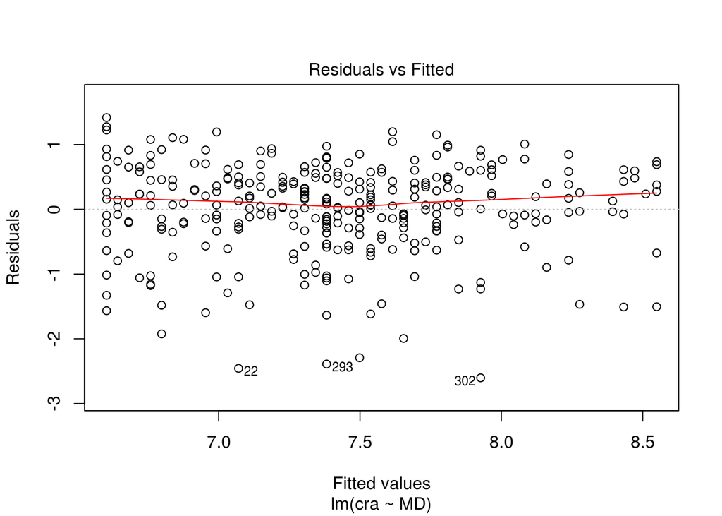

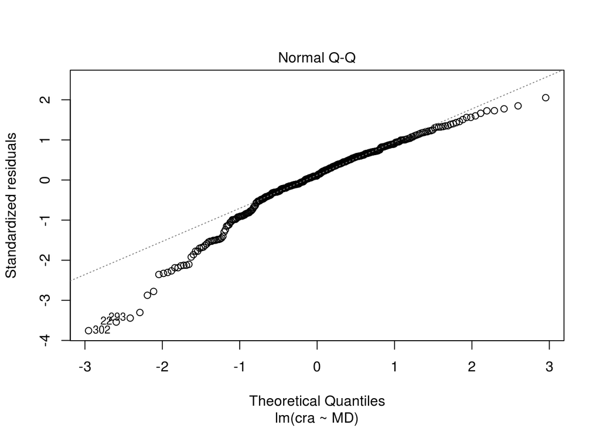

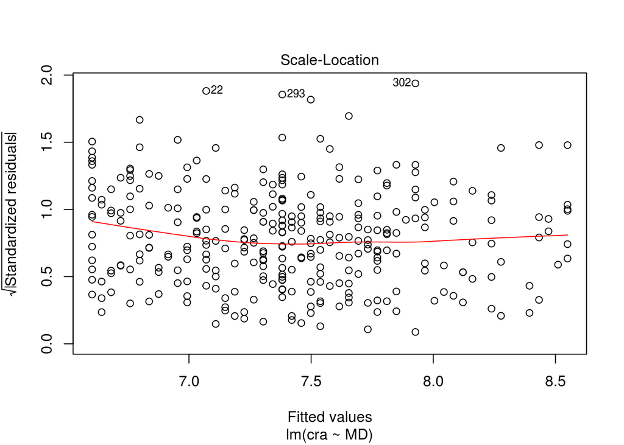

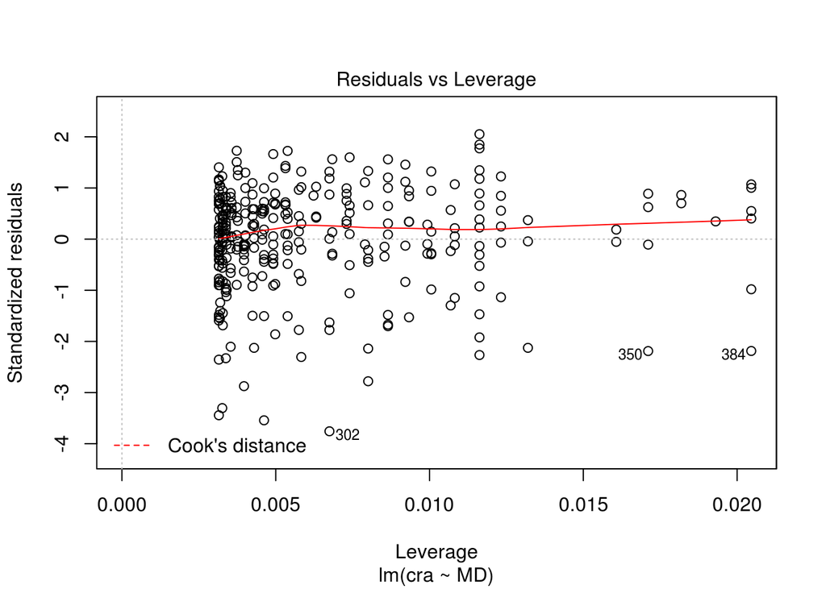

```r
plot(mycra2.best)
```

Para os dois juntos:

```r
mycra3 <- lm(cra~ MD + CI + AV+ IC, graduados.model.input)
summary(mycra3)
```

```
##
## Call:
## lm(formula = cra ~ MD + CI + AV + IC, data = graduados.model.input)
##
## Residuals:
##      Min       1Q   Median       3Q      Max
## -2.28864 -0.30907  0.08428  0.36548  1.22016
##
## Coefficients:
##             Estimate Std. Error t value Pr(>|t|)
## (Intercept)  1.76815    0.32474   5.445 1.13e-07 ***
## MD           0.19210    0.03098   6.201 1.99e-09 ***
## CI           0.12604    0.02834   4.448 1.25e-05 ***
## AV           0.12004    0.03247   3.697 0.000262 ***
## IC           0.30345    0.04881   6.217 1.82e-09 ***
## ---
## Signif. codes:  0 '***' 0.001 '**' 0.01 '*' 0.05 '.' 0.1 ' ' 1
##
## Residual standard error: 0.5621 on 282 degrees of freedom
##   (125 observations deleted due to missingness)
## Multiple R-squared:  0.5601, Adjusted R-squared:  0.5539
## F-statistic: 89.76 on 4 and 282 DF,  p-value: < 2.2e-16
```

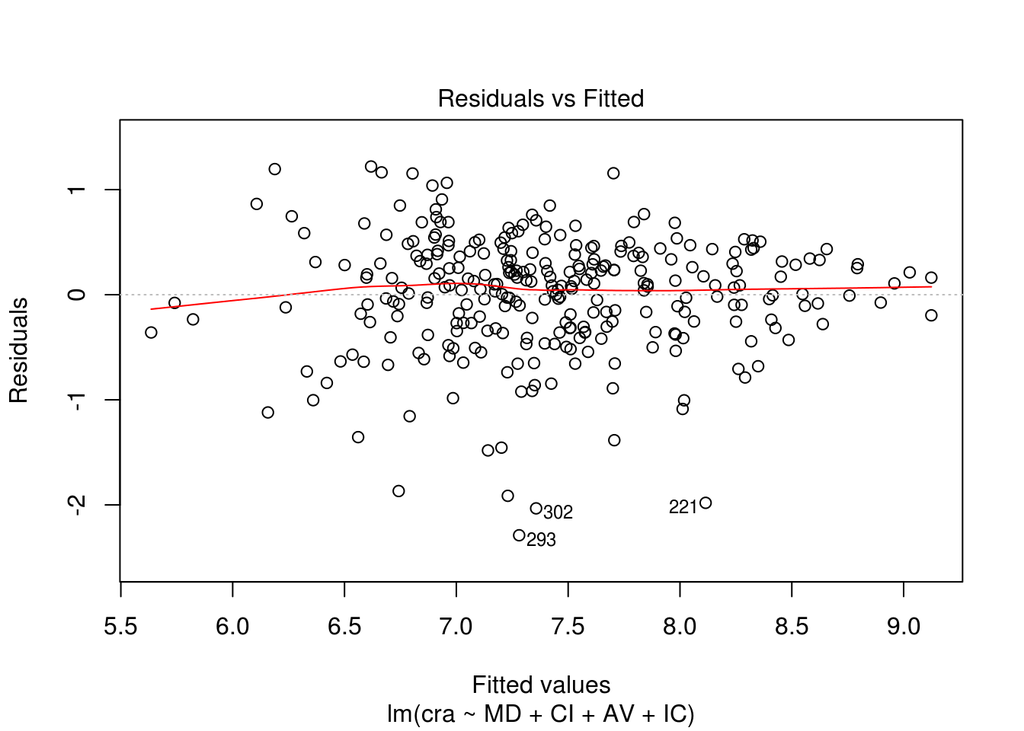

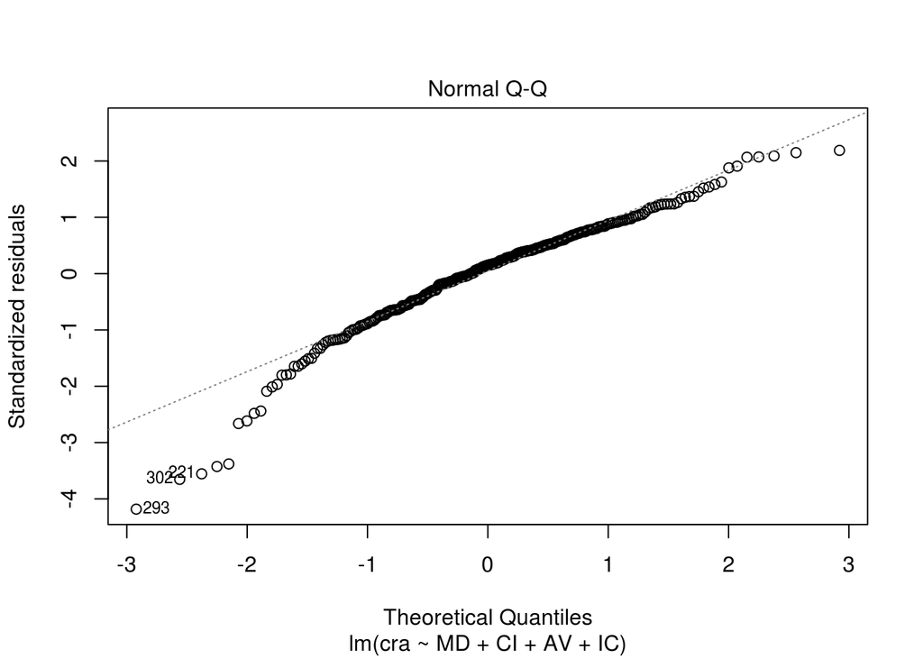

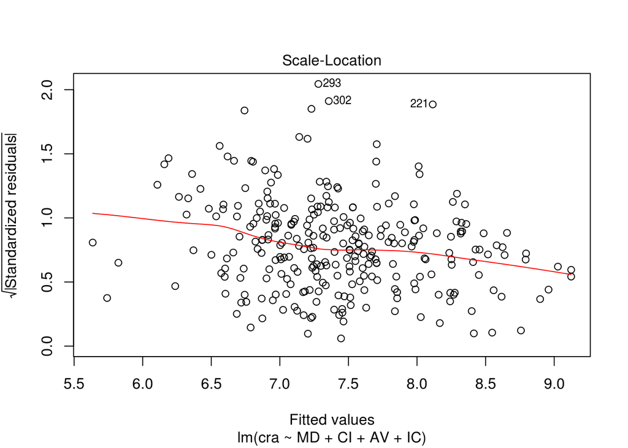

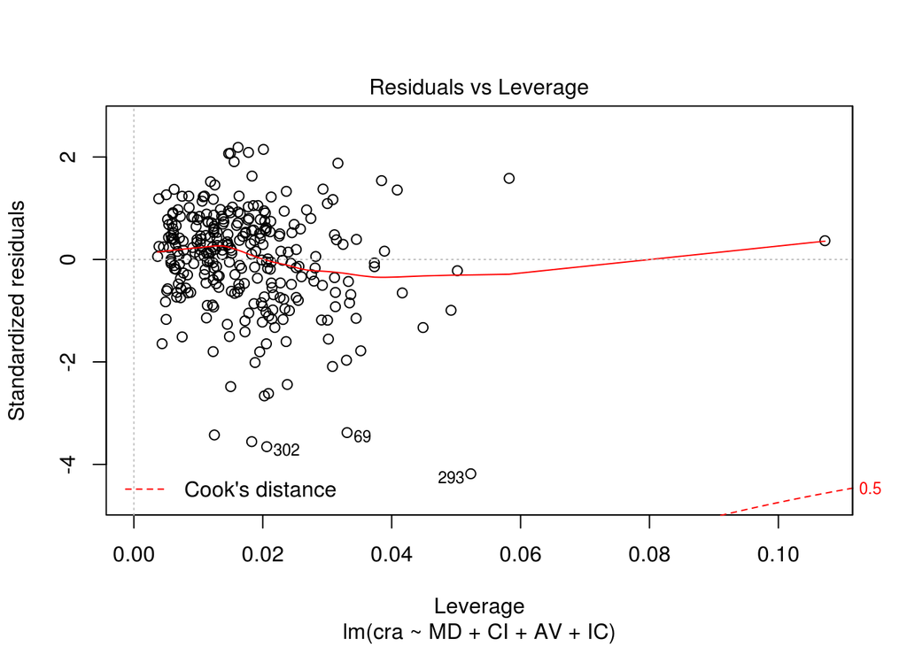

```r
plot(mycra3)
```

….

### Analise os plots de resíduos de cada variável e veja se algum (um ou mais) deles indica não aleatoriedade dos erros.

Quando observamos principalmente o gráfico do segundo período, sem as disciplinas com o p-value elevado, podemos ver uma distribuição quase uniforme dos resíduos, justamente pela relevância do fator que é a disciplina que mais influencia no cra. Assim como podemos ver também para o primeiro período quando “aparamos” as variáveis de entrada para o modelo de regressão linear

….

### Que período consegue explicar melhor o desempenho final (primeiro ou segundo)?

Pelos gráficos e principalmente pelo p-value podemos observar que mesmo o primeiro período possuindo mais cadeiras que influenciam o CRA, a principal cadeira que influencia se encontra no segundo período. Que é Matemática Discreta. Logo o segundo período é o que mais influencia.

….

### Use o melhor modelo encontrado para predizer o seu próprio desempenho e compare a predição com o seu CRA atual. Comente o resultado.

Para o meu caso teriamos que incluir Algebra Linear no segundo periodo, fazendo as variáveis assim

```r
AL <- graduados.model.input$Álgebra.Linear.I
mycra4.best <- lm(cra~MD + AL, graduados.model.input)
summary(mycra4.best)
```

```
##
## Call:
## lm(formula = cra ~ MD + AL, data = graduados.model.input)
##
## Residuals:
##      Min       1Q   Median       3Q      Max
## -1.80939 -0.25150  0.08228  0.40464  1.31786
##
## Coefficients:
##             Estimate Std. Error t value Pr(>|t|)
## (Intercept)  3.50068    0.29799  11.748  < 2e-16 ***
## MD           0.37094    0.03939   9.416  < 2e-16 ***
## AL           0.18737    0.04140   4.526 1.13e-05 ***
## ---
## Signif. codes:  0 '***' 0.001 '**' 0.01 '*' 0.05 '.' 0.1 ' ' 1
##
## Residual standard error: 0.579 on 168 degrees of freedom
##   (241 observations deleted due to missingness)
## Multiple R-squared:  0.5339, Adjusted R-squared:  0.5283
## F-statistic: 96.21 on 2 and 168 DF,  p-value: < 2.2e-16
```

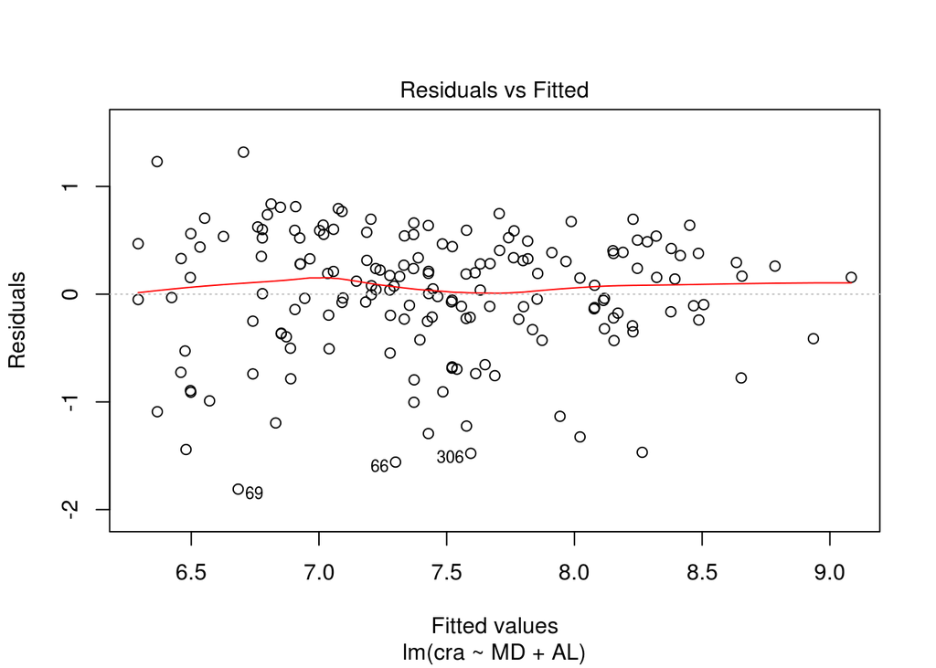

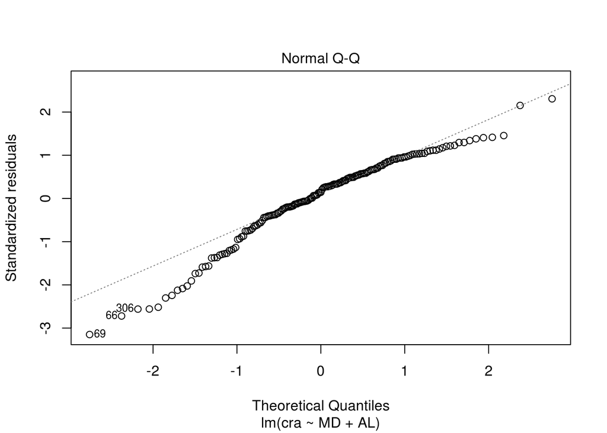

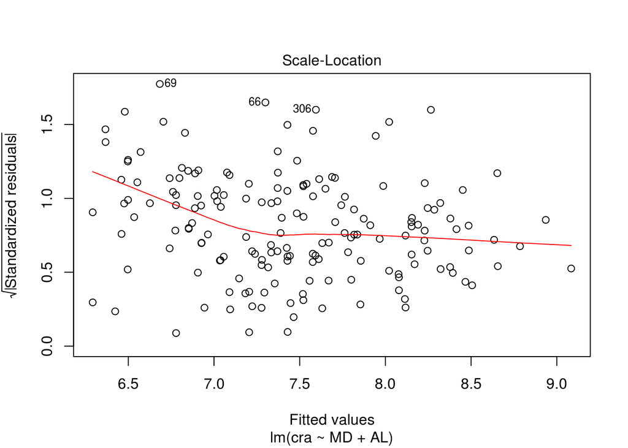

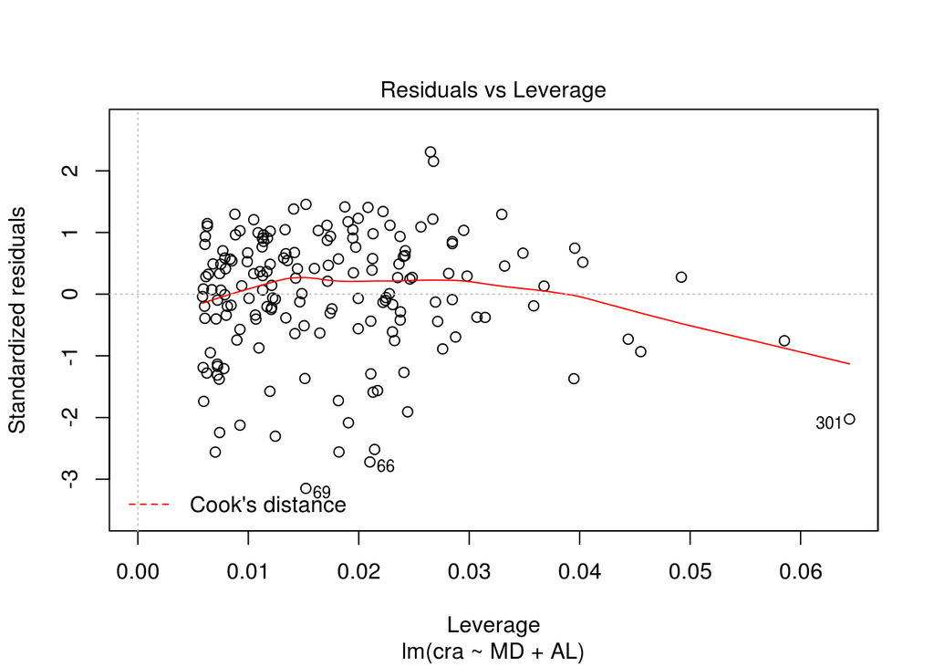

```r
plot(mycra4.best)
```

O que mostra uma concentração grande, principalmente entre 7 e 8,5. Um resultado conciso já que meu CRA é 7,9 e está dentro desse intervalo.